# STAT 184 Final Project

NYC AirBnb Data

Anna Leon

## Front Matter

```r
# clean up workspace environment
rm(list = ls())

# all packages used for the assignment
library(DataComputing)
library(readr)
library(dplyr)
```

## Goal of NYC Airbnb Data Exploration

The goal of my exploration of the NYC Airbnb data is to figure out what the relative pricing is between boroughs, neighborhoods, hosts, and various descriptions. My primary research question is what hosts, locations, and keywords should I look into if I want an expensive Airbnb? a cheap Airbnb?

## Data Access

### Reading in Data

```r
# Here, I read in my csv data file.

NYC <- read_csv("AB_NYC_2019.csv")
```

### Exploring the Data

```r
# Here, I use glimpse function to inspect the data. As you can see, there are 48,895 observations (rows), and there are 16 variables (columns).

glimpse(NYC)
```

```
Observations: 48,895
Variables: 16
$ id                             <dbl> 2539, 2595, 3647, 3831, 5022, 5099, 5121...
$ name                           <chr> "Clean & quiet apt home by the park", "S...
$ host_id                        <dbl> 2787, 2845, 4632, 4869, 7192, 7322, 7356...
$ host_name                      <chr> "John", "Jennifer", "Elisabeth", "LisaRo...
$ neighbourhood_group            <chr> "Brooklyn", "Manhattan", "Manhattan", "B...
$ neighbourhood                  <chr> "Kensington", "Midtown", "Harlem", "Clin...
$ latitude                       <dbl> 40.64749, 40.75362, 40.80902, 40.68514, ...
$ longitude                      <dbl> -73.97237, -73.98377, -73.94190, -73.959...
$ room_type                      <chr> "Private room", "Entire home/apt", "Priv...
$ price                          <dbl> 149, 225, 150, 89, 80, 200, 60, 79, 79, ...
$ minimum_nights                 <dbl> 1, 1, 3, 1, 10, 3, 45, 2, 2, 1, 5, 2, 4,...
$ number_of_reviews              <dbl> 9, 45, 0, 270, 9, 74, 49, 430, 118, 160,...
$ last_review                    <date> 2018-10-19, 2019-05-21, NA, 2019-07-05,...
$ reviews_per_month              <dbl> 0.21, 0.38, NA, 4.64, 0.10, 0.59, 0.40, ...
$ calculated_host_listings_count <dbl> 6, 2, 1, 1, 1, 1, 1, 1, 1, 4, 1, 1, 3, 1...
$ availability_365               <dbl> 365, 355, 365, 194, 0, 129, 0, 220, 0, 1...
```

```r
# Here, I use head to investigate the data. We can see that there is a wide variety of naming styles used to name listings; there are also some variables that may not be relevant to our analysis.

head(NYC)
```

| id | name | host_id | host_name | neighbourhood_group | neighbourhood | latitude | longitude | room_type | price | minimum_nights | number_of_reviews | last_review | reviews_per_month | calculated_host_listings_count | availability_365 |
| --- | --- | --- | --- | --- | --- | --- | --- | --- | --- | --- | --- | --- | --- | --- | --- |
| 2539 | Clean & quiet apt home by the park | 2787 | John | Brooklyn | Kensington | 40.64749 | -73.97237 | Private room | 149 | 1 | 9 | 2018-10-19 | 0.21 | 6 | 365 |
| 2595 | Skylit Midtown Castle | 2845 | Jennifer | Manhattan | Midtown | 40.75362 | -73.98377 | Entire home/apt | 225 | 1 | 45 | 2019-05-21 | 0.38 | 2 | 355 |
| 3647 | THE VILLAGE OF HARLEM....NEW YORK ! | 4632 | Elisabeth | Manhattan | Harlem | 40.80902 | -73.94190 | Private room | 150 | 3 | 0 |  | NA | 1 | 365 |
| 3831 | Cozy Entire Floor of Brownstone | 4869 | LisaRoxanne | Brooklyn | Clinton Hill | 40.68514 | -73.95976 | Entire home/apt | 89 | 1 | 270 | 2019-07-05 | 4.64 | 1 | 194 |
| 5022 | Entire Apt: Spacious Studio/Loft by central park | 7192 | Laura | Manhattan | East Harlem | 40.79851 | -73.94399 | Entire home/apt | 80 | 10 | 9 | 2018-11-19 | 0.10 | 1 | 0 |
| 5099 | Large Cozy 1 BR Apartment In Midtown East | 7322 | Chris | Manhattan | Murray Hill | 40.74767 | -73.97500 | Entire home/apt | 200 | 3 | 74 | 2019-06-22 | 0.59 | 1 | 129 |

## Data Wrangling

Before I begin wrangling the data, I am dropping variables id, host_name, last_review, minimum_nights, room_type, reviews_per_month, and availability_365 because they are not relevant to the analysis that I will be doing. I am also dropping latitude and longitude because I am using neighborhoods and neighborhood groups to classify location rather than latitude and longitude. I am also removing the calculated_host_listings_count variable because it will be more effective for me to summarise host listings data if I group by host_id myself.

I am also changing the name of the neighbourhood_group column to borough because that is the more common term used to describe the areas of NYC: Manhattan, Bronx, etc. I also am renaming the neighbourhood column to neighborhood to represent American spelling. I also shortened some of the variable/column names.

```r
# Here, I select only the variables I want, and rename a couple of the variables into more understandable names.

NYC <-
  NYC %>%
    select(name, host_id, neighbourhood, neighbourhood_group, price) %>%
    rename(borough = neighbourhood_group, neighborhood = neighbourhood)
```

### NYC Airbnb Hosts and the Average Prices they Charge

I want to find out how expensive each host generally prices their listings. Some hosts tend to own more expensive properties and charge higher prices than others. Clearly, if I am rich and want to look for only the most expensive and nice Airbnbs, I should contact one of the top ten hosts: hosts 5143901, 20582832, etc. If I want the cheapest Airbnb that I can find, then I should contact the host in the last row of the data table HostsCharges, the host that has the lowest average charge.

```r
# Here, I create the table HostsCharges by using group_by, summarise, and arrange functions with our data table NYC. HostCharges contains host_id and the average price that that host charges for their listings in the avg_charge column.

HostsCharges <-
  NYC %>%
    group_by(host_id) %>%
    summarise(avg_charge = round(mean(price, na.rm = TRUE))) %>%
    arrange(desc(avg_charge))

HostsCharges
```

| host_id | avg_charge |
| --- | --- |
| 5143901 | 10000 |
| 20582832 | 10000 |
| 72390391 | 10000 |
| 1235070 | 9999 |
| 3906464 | 9999 |
| 4382127 | 9999 |
| 18128455 | 8500 |
| 7407743 | 7500 |
| 11598359 | 6500 |
| 35303743 | 6500 |

[output cut: 990 more lines]

### Price Comparison between Boroughs

Here, I wanted to rank the boroughs based on average Airbnb price. As you can see, Manhattan is the most expensive borough, while Brooklyn comes in second. Additionally, the Bronx is the only borough with an average Airbnb price less than 100.

```r
# Here, I create table BoroughPrice to rank the boroughs by average price.

BoroughPrice <-
  NYC %>%
    group_by(borough) %>%
    summarise(avg_price = round(mean(price, na.rm=TRUE))) %>%
    arrange(desc(avg_price))

BoroughPrice
```

| borough | avg_price |
| --- | --- |
| Manhattan | 197 |
| Brooklyn | 124 |
| Staten Island | 115 |
| Queens | 100 |
| Bronx | 87 |

Here, I joined the BoroughPrice table above with another and created a column that tells whether a given listing is cheap, moderate, or expensive based on the average price of the borough in which it resides. Now, it is easy to tell which Airbnbs are expensive and which are not, without having to go through the guesswork of looking at tens of thousands of rows to compare prices.

```r
# Here, I create a table ListingPriceRange by using a left_join between NYC and the BoroughPrice table that I created above.

ListingPriceRange <-
  NYC %>%
    left_join(BoroughPrice) %>%
    select(name, borough, price, avg_price) %>%
    rename(borough_price = avg_price)
# Here, I add an additional column to the ListingPriceRange table called price_range and fill it with NA values. Later, I will fill this column in with non-NA values.

ListingPriceRange$price_range = NA

# Here, I run a for loop which iterates over every row in ListingPriceRange (there are 48895 rows). I used if, else if, and else statements to calculate whether the listing is cheap, moderate, or expensive for its respective borough. I defined cheap as less than $30 lower than the average price of the borough, expensive as more than $30 higher than the average price of the borough, and moderate as any price in between (no more than $30 more or less than the average price of the borough).

for(i in 1:48895){
  if((ListingPriceRange[i, 3] - ListingPriceRange[i, 4]) > 30){
    range <- "expensive"
  } else if((ListingPriceRange[i, 3] - ListingPriceRange[i, 4]) < -30){
    range <- "cheap"
  } else{
    range <- "moderate"
  }

  ListingPriceRange$price_range[i] <- range
}

# Here, I select only the columns that I want: name, borough, and price_range.

ListingPriceRange <-
  ListingPriceRange %>%
    select(name, borough, price_range)

ListingPriceRange
```

| name | borough | price_range |
| --- | --- | --- |
| Clean & quiet apt home by the park | Brooklyn | moderate |
| Skylit Midtown Castle | Manhattan | moderate |
| THE VILLAGE OF HARLEM....NEW YORK ! | Manhattan | cheap |
| Cozy Entire Floor of Brownstone | Brooklyn | cheap |
| Entire Apt: Spacious Studio/Loft by central park | Manhattan | cheap |
| Large Cozy 1 BR Apartment In Midtown East | Manhattan | moderate |
| BlissArtsSpace! | Brooklyn | cheap |
| Large Furnished Room Near B'way | Manhattan | cheap |
| Cozy Clean Guest Room - Family Apt | Manhattan | cheap |
| Cute & Cozy Lower East Side 1 bdrm | Manhattan | cheap |

[output cut: 990 more lines]

### Price Comparison between Neighborhoods

I then carried out a similar investigation on the neighborhoods, rather than individual listings. Again, I want to classify each neighborhood as cheap, moderate, or expensive, as it compares to the average price of Airbnbs in its borough. That way users who want to stay in Queens, for example, can determine which neighborhoods within Queens are moderately priced, aka close to the average price of the borough, or which neighborhoods are cheap or expensive.

```r
# Here, I create the table NeighborhoodAvgPrice, which includes columns neighborhood and avg_price, which represents the average listing price of that neighborhood.

NeighborhoodAvgPrice <-
  NYC %>%
    group_by(neighborhood) %>%
    summarise(avg_price = round(mean(price, na.rm=TRUE)))

# Here, I create a table called HoodinBorough, which contains columns borough, neighborhood, and count, which represents the number of listings in that neighborhood.

HoodinBorough <-
  NYC %>%
    group_by(borough, neighborhood) %>%
    summarise(count = n())

# Here, I create the table HoodInfo by joining NeighborhoodAvgPrice, HoodinBorough, and BoroughPrice.

HoodInfo <-
  NeighborhoodAvgPrice %>%
    left_join(HoodinBorough) %>%
    left_join(BoroughPrice, by = c("borough" = "borough")) %>%
    rename(avg_price_hood = avg_price.x, avg_price_borough = avg_price.y)
# Here, I create table HoodPriceRange by selecting only the columns neighborhood, avg_price_hood, avg_price_borough, and borough from HoodInfo. I then added an additional column to the table, price_range, that I temporarily filled with NA values.

HoodPriceRange <-
  HoodInfo %>%
    select(neighborhood, avg_price_hood, avg_price_borough, borough)

HoodPriceRange$price_range = NA

# Here, I run another for loop very similar to the one in the previous section, using if, else if, and else statements to classify neighborhoods as cheap, moderate, or expensive for their respective boroughs.

for(i in 1:221){
  if((HoodInfo[i, 2] - HoodInfo[i, 5]) > 30){
    range <- "expensive"
  } else if((HoodInfo[i, 2] - HoodInfo[i, 5]) < -30){
    range <- "cheap"
  } else{
    range <- "moderate"
  }

  HoodPriceRange$price_range[i] <- range
}

# Here, I select only the relevant columns: neighborhood, borough, and price_range.

HoodPriceRange <-
  HoodPriceRange %>%
    select(neighborhood, borough, price_range)

HoodPriceRange
```

| neighborhood | borough | price_range |
| --- | --- | --- |
| Allerton | Bronx | moderate |
| Arden Heights | Staten Island | cheap |
| Arrochar | Staten Island | moderate |
| Arverne | Queens | expensive |
| Astoria | Queens | moderate |
| Bath Beach | Brooklyn | cheap |
| Battery Park City | Manhattan | expensive |
| Bay Ridge | Brooklyn | moderate |
| Bay Terrace | Queens | expensive |
| Bay Terrace, Staten Island | Staten Island | moderate |

[output cut: 211 more lines]

### “Cozy” Airbnbs

Now, I will be investigating the difference in pricing of airbnbs that do not have the word cozy in their title with those that do. It turns out that airbnbs that are described as cozy typically cost less than their counterparts. This may be due to the fact that cozy typically means a smaller space.

```r
# Here, I create a table called Cozy using regex and the filter and grepl functions. I want to find all of the listings that mention the word "cozy" in their names. I also created the table NotCozy to find the Airbnbs that do not mention "cozy" in their names.

Cozy <-
  NYC %>%
    filter(grepl("cozy", name, ignore.case = TRUE))

Cozy
```

| name | host_id | neighborhood | borough | price |
| --- | --- | --- | --- | --- |
| Cozy Entire Floor of Brownstone | 4869 | Clinton Hill | Brooklyn | 89 |
| Large Cozy 1 BR Apartment In Midtown East | 7322 | Murray Hill | Manhattan | 200 |
| Cozy Clean Guest Room - Family Apt | 7490 | Upper West Side | Manhattan | 79 |
| Cute & Cozy Lower East Side 1 bdrm | 7549 | Chinatown | Manhattan | 150 |
| Cozy 1BD on Central Park West in New York City | 56094 | Upper West Side | Manhattan | 151 |
| Very, very cozy place | 60252 | Williamsburg | Brooklyn | 80 |
| Cozy 2 BR in Williamsburg | 72014 | Williamsburg | Brooklyn | 145 |
| Cozy Bedroom in Williamsburg 3 BR | 72014 | Williamsburg | Brooklyn | 85 |
| COZY QUIET room 4 DOOGLERS! | 83257 | Chelsea | Manhattan | 98 |
| Times Square, Safe, Clean and Cozy! | 59734 | Hell's Kitchen | Manhattan | 59 |

[output cut: 990 more lines]

```r
NotCozy <-
  NYC %>%
    filter(!grepl("cozy", name, ignore.case = TRUE))

NotCozy
```

| name | host_id | neighborhood | borough | price |
| --- | --- | --- | --- | --- |
| Clean & quiet apt home by the park | 2787 | Kensington | Brooklyn | 149 |
| Skylit Midtown Castle | 2845 | Midtown | Manhattan | 225 |
| THE VILLAGE OF HARLEM....NEW YORK ! | 4632 | Harlem | Manhattan | 150 |
| Entire Apt: Spacious Studio/Loft by central park | 7192 | East Harlem | Manhattan | 80 |
| BlissArtsSpace! | 7356 | Bedford-Stuyvesant | Brooklyn | 60 |
| Large Furnished Room Near B'way | 8967 | Hell's Kitchen | Manhattan | 79 |
| Beautiful 1br on Upper West Side | 7702 | Upper West Side | Manhattan | 135 |
| Central Manhattan/near Broadway | 7989 | Hell's Kitchen | Manhattan | 85 |
| Lovely Room 1, Garden, Best Area, Legal rental | 9744 | South Slope | Brooklyn | 89 |
| Wonderful Guest Bedroom in Manhattan for SINGLES | 11528 | Upper West Side | Manhattan | 85 |

[output cut: 990 more lines]

```r
# Here, I calculated the average price of Cozy Airbnbs and NotCozy Airbnbs, to compare the two.

Cozy %>%
  summarise(ave_cost = round(mean(price, na.rm = TRUE), 2))
```

| ave_cost |
| --- |
| 104.76 |

```r
NotCozy %>%
  summarise(ave_cost = round(mean(price, na.rm = TRUE), 2))
```

| ave_cost |
| --- |
| 158.32 |

## Data Visualization

### Histogram and Scatterplot of Average Prices Charged by Hosts

Below is a Histogram of the average charge on the x axis and the number of hosts is on the y axis. It is clear that the majority of hosts typically price their listings at less than $300, but there are definitely outliers.

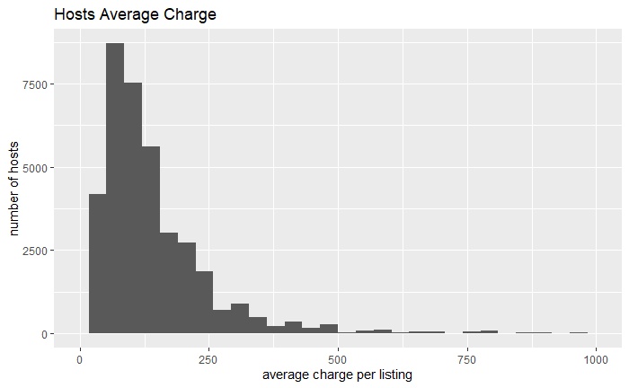

```r
# Here, I create a histogram using ggplot and the HostsCharges table from earlier in this report. I limited the x axis to 1000 to remove some outliers and focus on the range of average charges that had the majority of data in it.

HostsCharges %>%
  ggplot(aes(x = avg_charge)) +
  geom_histogram() +
  xlim(0, 1000) +
  ylab("number of hosts") +
  xlab("average charge per listing") +
  ggtitle("Hosts Average Charge")
```

Below is a similar plot of the same data, except this time with a scatterplot and smoother. The smoother allows us to see the trend in the data. As average charge increases the number of hosts decreases.

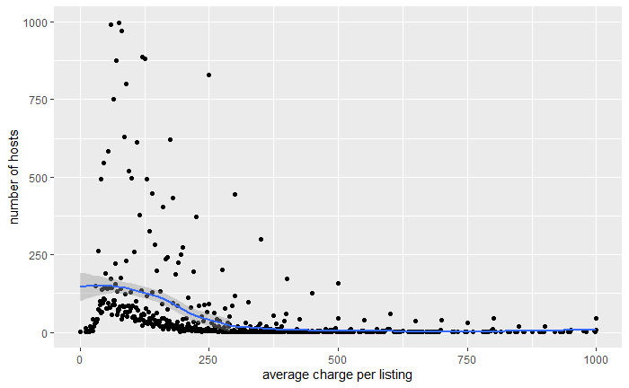

```r
# Here is a similar plot using the same data; however, this time I created a scatterplot and used a smoother over top of it.

HostsCharges %>%
  group_by(avg_charge) %>%
  summarise(count = n()) %>%
  ggplot(aes(x = avg_charge, y = count)) +
  geom_point() +
  geom_smooth() +
  xlim(0, 1000) +
  ylim(0, 1000) +
  ylab("number of hosts") +
  xlab("average charge per listing")
```

### Most Expensive Neighborhoods Scatterplot

Below is a scatterplot of the top five most expensive neighborhoods for Airbnbs in NYC. We can see that the most expensive neighborhood is Fort Wadsworth; however, if I am a customer who wants the nicest and priciest Airbnbs I could look into all five of these neighborhoods because they are all relatively pricey.

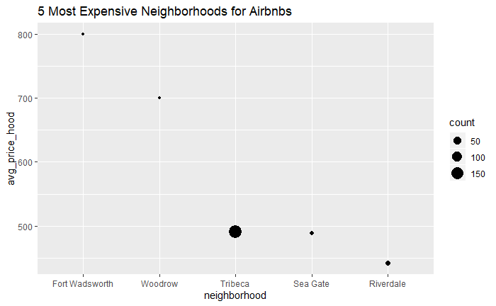

```r
# Here, I created a table HoodShort, which is just the head of HoodInfo arranged by descending average price of the neighborhood.

HoodShort <-
  HoodInfo %>%
    arrange(desc(avg_price_hood)) %>%
    head(5)

# Here, I used a factor to rearrange the x axis of the below scatterplot so that it was in order of decreasing average price in the neighborhood.

HoodShort$neighborhood <- factor(HoodShort$neighborhood,levels = c("Fort Wadsworth", "Woodrow", "Tribeca", "Sea Gate", "Riverdale"))

# Here, I create the scatterplot from HoodShort, using ggplot. I mapped count to size to represent the number of Airbnbs in each neighborhood to gain perspective on how many listings actually went into the calculation of each neighborhood's average price.

HoodShort %>%
  ggplot(aes(x = neighborhood, y = avg_price_hood)) +
  geom_point(aes(size = count)) +
  ggtitle("5 Most Expensive Neighborhoods for Airbnbs")
```

### Price Distribution of all Neighborhoods - Faceted by Borough

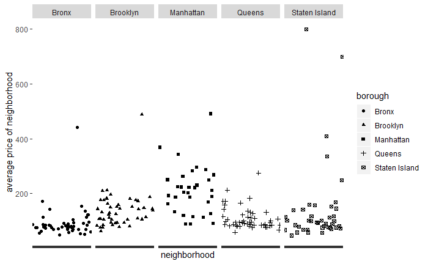

```r
# Here, I created a scatterplot of all of the neighborhoods and their average prices. I also faceted by borough, and mapped borough to shape as well so that it was clear which points were a part of which borough.

HoodInfo %>%
  ggplot(aes(x = neighborhood, y = avg_price_hood)) +
  geom_point(aes(shape = borough)) +
  facet_grid( ~ borough) +
  ylab("average price of neighborhood") +
  theme(axis.text.x = element_blank())
```

### Listing Price Range per Borough

The following boxplot shows the price distribution of listings, faceted by borough. I removed some of the outliers by adjusting the y axis so that it only went up to 750. Note that all boroughs had a few upper price point Airbnbs removed from the plot, so that the majority of price points were easier to see and analyze. Even though Manhattan is the most expensive, it also has the highest interquartile range. Brooklyn has the second largest interquartile range.

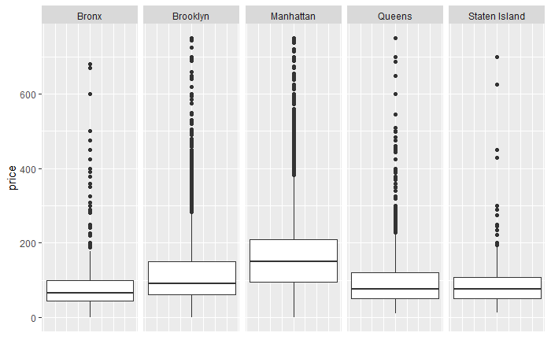

```r
# Here, I reordered the x axis using a factor so that the levels were in the order of cheap, moderate, then expensive.

ListingPriceRange$price_range <- factor(ListingPriceRange$price_range,levels = c("cheap", "moderate", "expensive"))

# Here, I got the ListingPriceRange into glyph ready form by using a left_join with NYC.

GlyphReady <-
  ListingPriceRange %>%
    left_join(NYC) %>%
    select(borough, price)
# Here, I plotted the table GlyphReady with ggplot and geom_boxplot to show the price distributions in each borough.

GlyphReady %>%
  ggplot(aes(y = price)) +
  geom_boxplot() +
  facet_grid( ~ borough) +
  ylim(0, 750) +
  theme(axis.text.x = element_blank(), axis.ticks.x = element_blank())
```

The boxplot below is the same plot as above, except not faceted by borough, so it is just for all listings in general. I again limited the y axis to (0,750). We can see from the boxplot that the median price of all of the listings in the dataset is just slightly above $100.

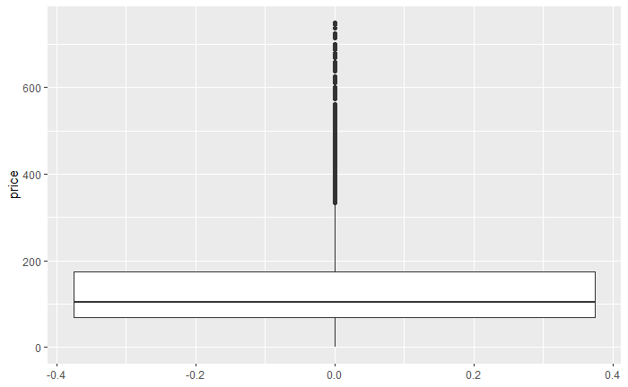

```r
# Here, I used the same data as above to create a similar plot, except this time it is not faceted by borough. This allows us to see the general makeup of our listing data.

GlyphReady %>%
  ggplot(aes(y = price)) +
  geom_boxplot() +
  ylim(0, 750)
```

### Neighborhood Price Range per Borough

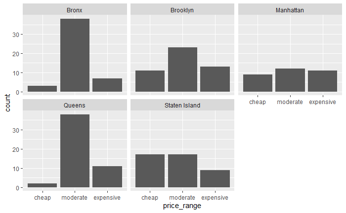

```r
# Here, I again used a factor to rearrange the order of the x axis levels.

HoodPriceRange$price_range <- factor(HoodPriceRange$price_range,levels = c("cheap", "moderate", "expensive"))

# Here, I used ggplot to make a bar graph with HoodPriceRange, faceting by borough.

HoodPriceRange %>%
  ggplot(aes(x = price_range)) +
  geom_bar() +
  facet_wrap( ~ borough)
```